# getspanel: Getting Started

The `getspanel` package can be downloaded and installed from CRAN [here](https://cran.r-project.org/package=getspanel) by simply using:

```r
install.packages("getspanel")
```

The source code of the package is on [GitHub](https://github.com/moritzpschwarz/getspanel) and the development version can be installed using:

```
# install.packages("devtools")
devtools::install_github("moritzpschwarz/getspanel", ref = "devel")
```

Once installed we need to load the library:

```r
library(getspanel)
library(fixest)
```

Currently the package is called **getspanel** to align with the **gets** package, but it’s main function of course remains the **isatpanel** function.

The **isatpanel** function implements the empirical break detection algorithm that is described in a [paper by Felix Pretis and Moritz Schwarz](https://papers.ssrn.com/sol3/papers.cfm?abstract_id=4022745) and was applied to a study by Nico Koch and colleagues on EU Road CO<sub>2</sub> emissions, which was [published in Nature Energy in 2022](https://www.nature.com/articles/s41560-022-01095-6).

# The isatpanel function

We first load some data of EU CO2 Emissions in the housing sector.

```r
data("EUCO2residential")
head(EUCO2residential)
# A tibble: 6 × 9
  country  year  lgdp  lhdd  lcdd urban av.rate     pop agg.directem
  <chr>   <dbl> <dbl> <dbl> <dbl> <dbl>   <dbl>   <dbl>        <dbl>
1 Austria  1969  25.6    NA    NA  65.2      NA      NA           NA
2 Austria  1970  25.7    NA    NA  65.3      NA      NA           NA
3 Austria  1971  25.8    NA    NA  65.3      NA 7500482           NA
4 Austria  1972  25.8    NA    NA  65.3      NA 7544201           NA
5 Austria  1973  25.9    NA    NA  65.3      NA 7586115           NA
6 Austria  1974  25.9    NA    NA  65.3      NA 7599038           NA

# let's subset this a little bit to speed this up
EUCO2residential <- EUCO2residential[EUCO2residential$year > 2000 &
                                       EUCO2residential$country %in% c("Germany", "Austria",
                                                                       "Belgium", "Italy",
                                                                       "Sweden", "Denmark"),]

# let's create a log emissions per capita variable
EUCO2residential$lagg.directem_pc <- log(EUCO2residential$agg.directem/EUCO2residential$pop)

# and let's also turn off printing the intermediate output from isatpanel
options(print.searchoutput = FALSE)
```

Let’s look at how we input what we want to model. Each `isatpanel` command takes:

## Basics

- A specification of the source data, the group and time variable and the group-time characteristics. This can be entered into the function in two ways:
1. In the **gets** package style i.e. using vectors and matrices to specify `y`, `mxreg`, `time` and `id`
2. But also in a form that resembles the `lm` and `plm` specification i.e. inputting a `data.frame` (or `matrix` or `tibble`), a `formula` argument as well as character vectors for `index` (in the form `c("group_variable_name", "time_variable_name")`)
- A an argument for the Fixed Effect Specification using `effect`.

Using the new method

```r
is_lm <- isatpanel(data = EUCO2residential,
                   formula = lagg.directem_pc ~ lgdp + I(lgdp^2) + pop,
                   index = c("country","year"),

                   effect = "twoways",

                   fesis = TRUE)
```

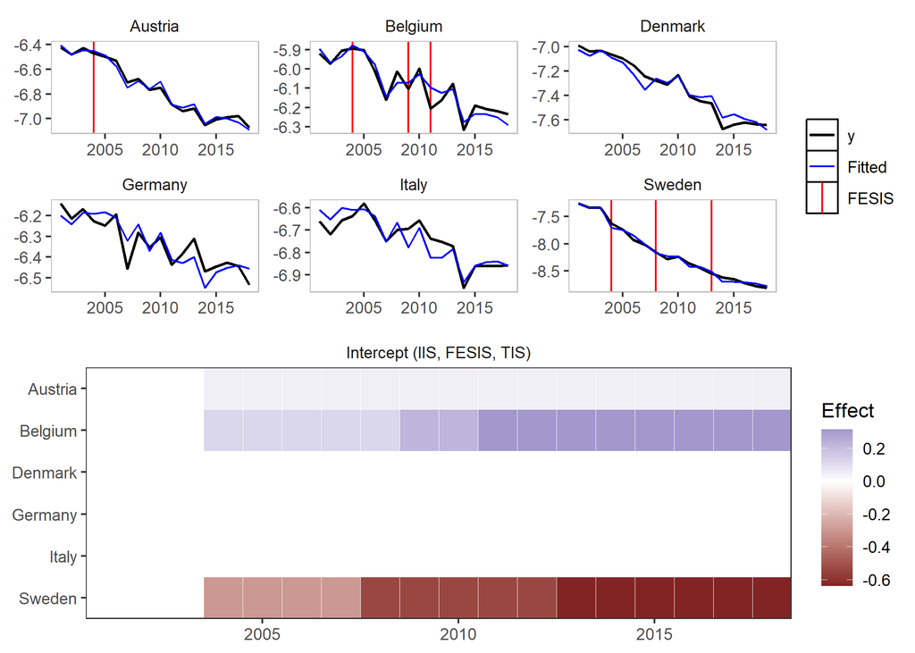

Using the traditional method

```r
is_gets <- isatpanel(y = EUCO2residential$lagg.directem_pc,
                     mxreg = EUCO2residential$lgdp,
                     time = EUCO2residential$year,
                     id = EUCO2residential$country,

                     effect = "twoways",

                     fesis = TRUE)
```

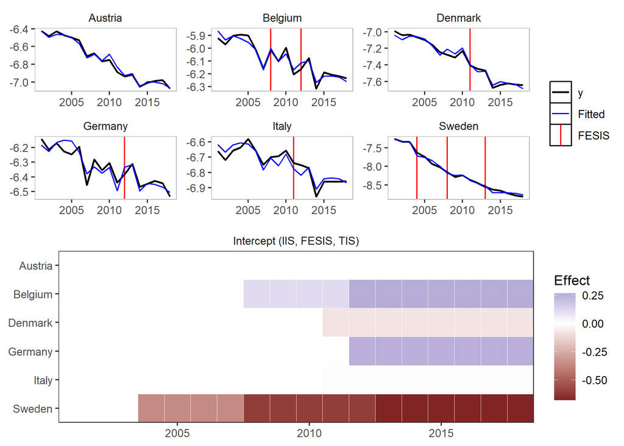

From here onwards, I will use the `lm` notation.

## Plotting

We can plot these simply using the default plotting methods (rely on the **ggplot2** package):

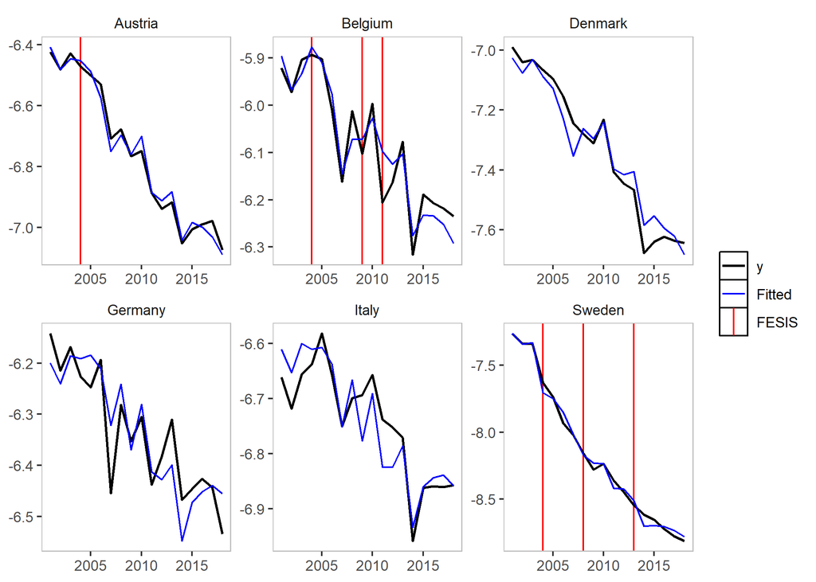

```r
plot(is_lm)
```

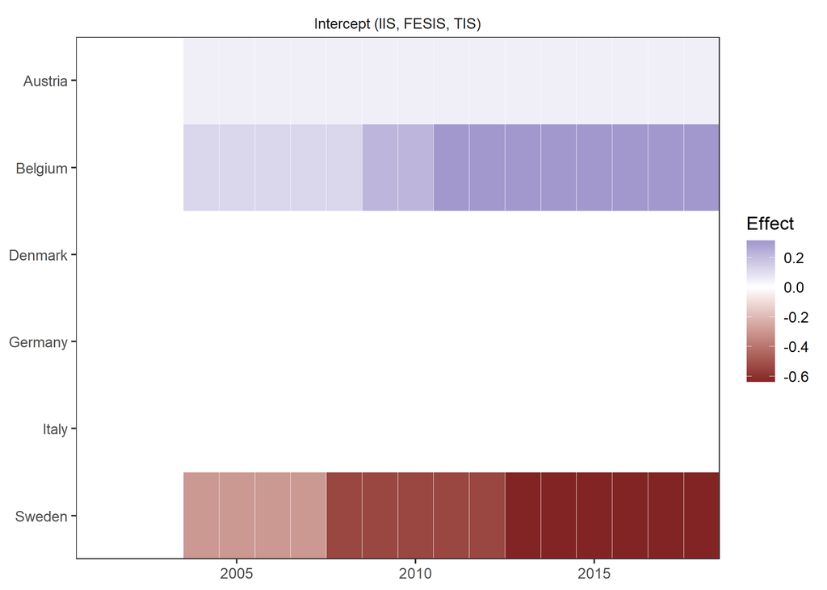

```r
plot_grid(is_lm)
```

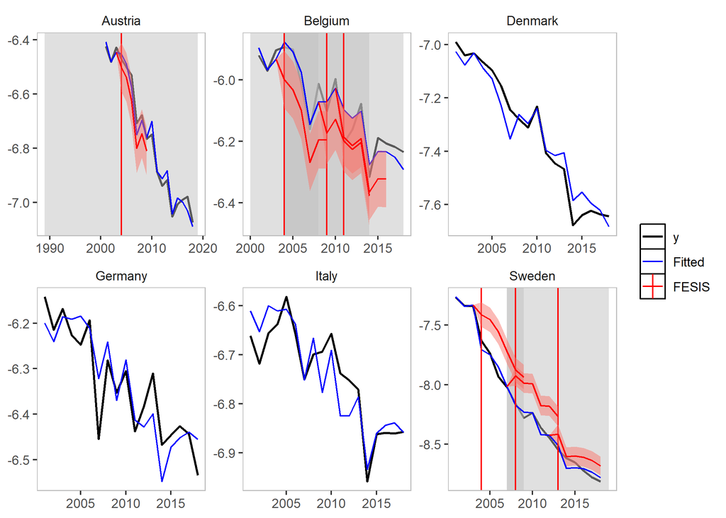

```r
plot_counterfactual(is_lm)
```

## Saturation Methods

### Impulse Indicator Saturation

This argument works just as in the **gets** package. The method simply adds a `0` and `1` dummy for each observation.

Simply set `iis = TRUE`.

```r
iis_example <- isatpanel(data = EUCO2residential,
                         formula = lagg.directem_pc ~ lgdp + I(lgdp^2) + pop,
                         index = c("country","year"),

                         effect = "twoways",

                         iis = TRUE,
                         fesis = TRUE)
```

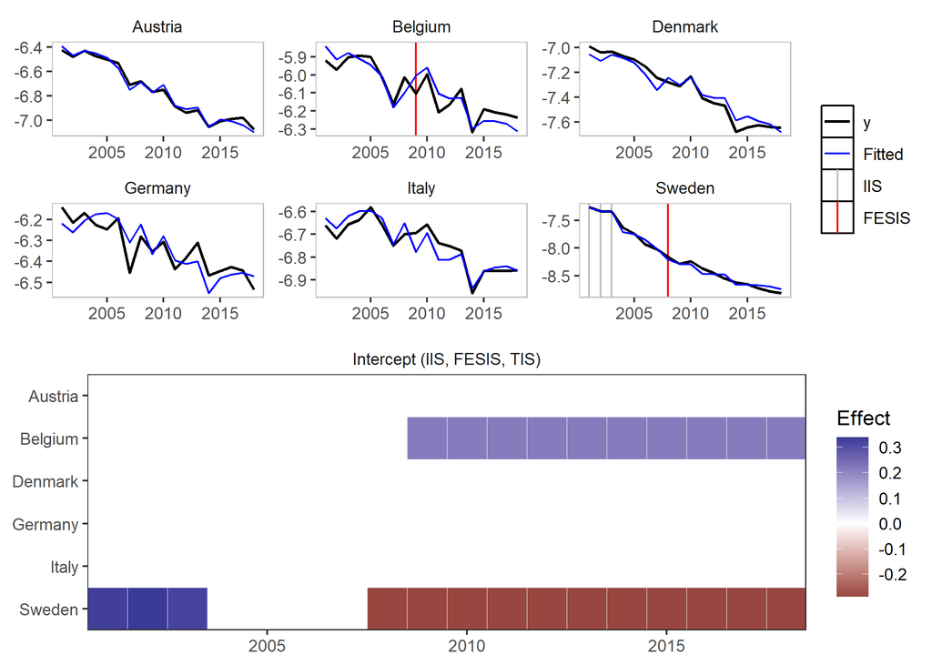

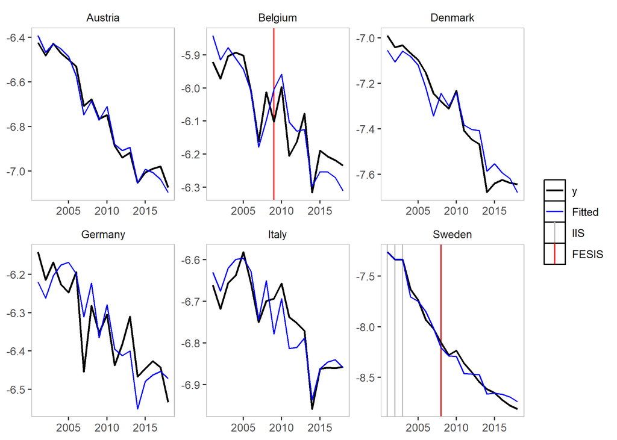

```r
plot(iis_example)
```

### Step Indicator Saturation

Traditional Step Indicator Saturation does not make sense in a panel setting. Therefore, the **gets** function of `sis` is disabled.

### Joint Step Indicator Saturation

It is possible, however, to consider Step Indicator Saturation with common breaks across individuals. Such indicators would be collinear, if `effects = c("twoways")` or `effects = c("time")` i.e. if Time Fixed Effects are included.

If, however, `effect = "individual"` then we can use `jsis = TRUE` to select over all individual time fixed effects.

```r
jsis_example <- isatpanel(data = EUCO2residential,
                          formula = lagg.directem_pc ~ lgdp + I(lgdp^2) + pop,
                          index = c("country","year"),

                          effect = "individual",

                          jsis = TRUE)
```

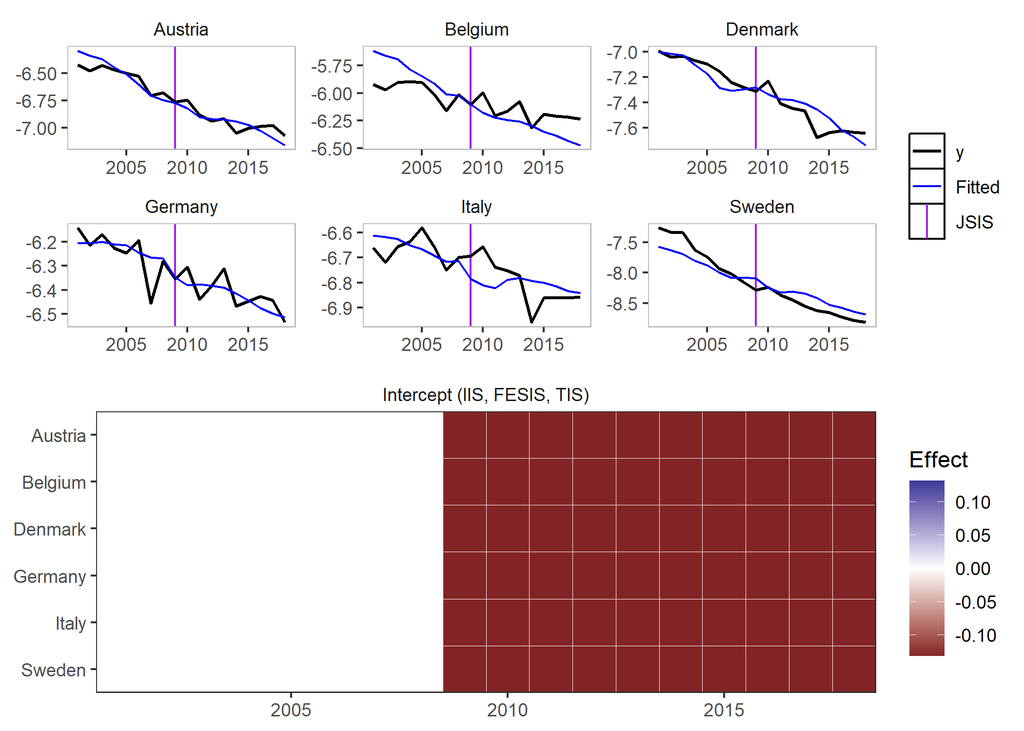

### Coefficient Step Indicator Saturation

**Note:** This method has only been tested using the `lm` implementation (using `data`, `formula`, and `index`).

This method allows detection of coefficient breaks that are common across all groups. It is the interaction between `jsis` and the relevant coefficient.

To illustrate this, as well as the advantages of using the `lm` approach, we include a non-linear term of the lgdp variable using `I(lgdp^2)`:

```r
csis_example <- isatpanel(data = EUCO2residential,
                          formula = lagg.directem_pc ~ lgdp + I(lgdp^2) + pop,
                          index = c("country","year"),

                          effect = "twoways",
                          t.pval = 0.05,

                          csis = TRUE)
```

By default, all coefficients will be interacted and added to the indicator list - but his can be controlled using the `csis_var`, which takes a character vector of column names i.e. `csis_var = "lgdp"`.

```r
csis_example2 <- isatpanel(data = EUCO2residential,
                           formula = lagg.directem_pc ~ lgdp + I(lgdp^2) + pop,
                           index = c("country","year"),

                           effect = "twoways",

                           csis = TRUE,
                           csis_var = "lgdp")
```

### Fixed Effect Step Indicator Saturation

This is equivalent to supplying a constant to the mxbreak argument in the old method. This essentially breaks the group-specific intercept i.e. the individual fixed effect.

```r
fesis_example <- isatpanel(data = EUCO2residential,
                           formula = lagg.directem_pc ~ lgdp + I(lgdp^2) + pop,
                           index = c("country","year"),

                           effect = "twoways",

                           fesis = TRUE)
```

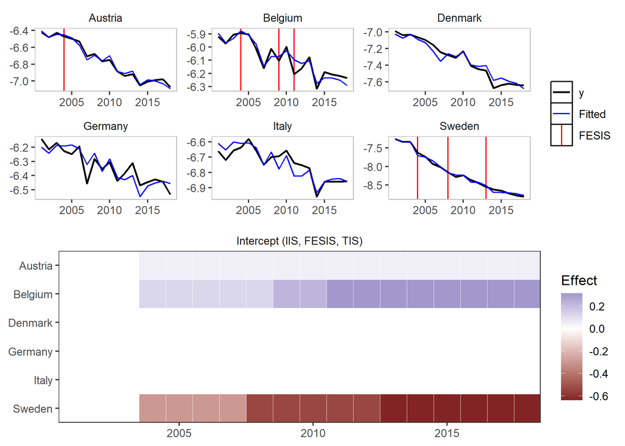

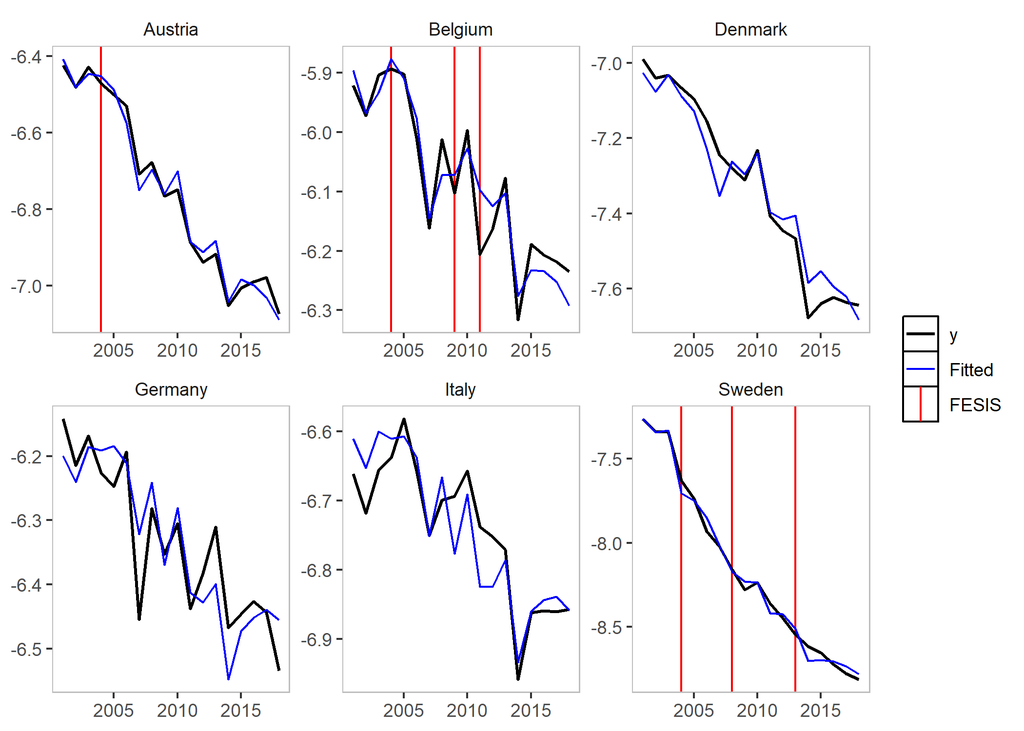

```r
plot(fesis_example)
```

Similar to the `csis_var` idea, we can specify the `fesis` method for a subset of individuals as well using the `fesis_id` variable, which takes a character vector of individuals. In this case we can use e.g. `fesis_id = c("Austria","Denmark")`.

```r
fesis_example2 <- isatpanel(data = EUCO2residential,
                           formula = lagg.directem_pc ~ lgdp + I(lgdp^2) + pop,
                           index = c("country","year"),

                           effect = "twoways",

                           fesis = TRUE,
                           fesis_id = c("Austria","Denmark"))
```

```r
plot(fesis_example2)
```

[output not shown]